# Wish Take Home Assessment

## Author: Aaron W Chen

Provided 2 CSVs

Submit a PDF with what you find about the business. What are growth opportunities? What else is interesting?

```python
import pandas as pd
import numpy as np
import csv
import matplotlib as pyplot
%matplotlib inline
```

```python
visitor_path = "../../data/raw/visitors_202001.csv"
transaction_path = "../../data/raw/transactions_202001.csv"

visitor_df = pd.read_csv(visitor_path);
transaction_df = pd.read_csv(transaction_path);
```

```python
visitor_df.info()
```

```
<class 'pandas.core.frame.DataFrame'>
RangeIndex: 1981904 entries, 0 to 1981903
Data columns (total 9 columns):
user_id       object
client        object
ip_country    object
gender        object
year_born     int64
channel       object
time          int64
minutes       int64
session_id    object
dtypes: int64(3), object(6)
memory usage: 136.1+ MB
```

```python
transaction_df.info()
```

```
<class 'pandas.core.frame.DataFrame'>
RangeIndex: 120662 entries, 0 to 120661
Data columns (total 7 columns):
user_id           120662 non-null object
transaction_id    120662 non-null object
time              120662 non-null int64
country           119311 non-null object
items             120662 non-null int64
total             120662 non-null float64
returned_items    120662 non-null int64
dtypes: float64(1), int64(3), object(3)
memory usage: 6.4+ MB
```

## Creating variables for analysis later

```python
single_transaction_users = visitor_df['user_id'].value_counts()[visitor_df['user_id'].value_counts() == 1].keys().tolist()
print(single_transaction_users[:5]);

paid_users_df = visitor_df[visitor_df['channel'] == 'paid'];
paid_users = paid_users_df['user_id'].unique().tolist()

unpaid_users_df = visitor_df[visitor_df['channel'] != 'paid'];
unpaid_users = unpaid_users_df['user_id'].unique().tolist()

duplicate_sessions = visitor_df['session_id'].value_counts()[visitor_df['session_id'].value_counts() > 1].keys().tolist();

long_browsers = visitor_df[visitor_df['minutes'] > 30]['user_id'].tolist();

short_browsers = visitor_df[visitor_df['minutes'] <= 30]['user_id'].tolist();
```

```
['98770c8cc14b610566b5a32b1c8f5c29', 'a6addb31b1a1ac68e26c70a3d70e698b', 'fc4e1c94760d1166c2cfae04ad8edf80', '56f850da9cc2ff3c2ca8d0660d9bb2f4', '7bce0e9e7395b375ac7cb83f3ab64c4b']
```

## Effect of null countries in transactions table?

```python
transaction_df[transaction_df['country'].isnull()]
```

|  | user_id | transaction_id | time | country | items | total | returned_items |
| --- | --- | --- | --- | --- | --- | --- | --- |
| 55 | 2e2ceb3a5937850472327e3316f56ed6 | e2ffb5fbf999175359bae2e1aaabb7c3 | 1541298046 | NaN | 1 | 30.93 | 0 |
| 145 | e7840693d54cb8552871b374ab1a9952 | d1df3eb63474ae430a7d4c9847666731 | 1539998459 | NaN | 1 | 46.39 | 0 |
| 202 | 320a0ee0121bd710a635e8cd58913993 | 7e0442b14b5ff925e0457fd88e45c45c | 1525397829 | NaN | 1 | 61.86 | 0 |
| 212 | d8fb3e8c857c1473103497421a608402 | 5d45369c0e474d9702313487f5559d42 | 1525398484 | NaN | 1 | 21.65 | 0 |
| 290 | 30ad2068f283d07eae8048d1808e0412 | 8b199779179149a642ab8e925a7fb4a4 | 1536284344 | NaN | 1 | 34.02 | 0 |
| ... | ... | ... | ... | ... | ... | ... | ... |
| 119888 | b474a945c89de9c08c711a0db4e0f737 | 215778005e7ca68c7d3b1ed69e36f932 | 1543570212 | NaN | 1 | 9.28 | 0 |
| 119914 | 610ebd5a615348c47061078c1d3b0c8c | 0195c7210b2de68d193a7defe91cae4f | 1534250068 | NaN | 3 | 30.93 | 0 |
| 120082 | bc9cd4ae47f8f29834635b394d2b187c | 7b162649e732383fe6b6988e91f5b027 | 1539506178 | NaN | 1 | 9.28 | 0 |
| 120346 | f786b1815b1cde29ea401681ece47c86 | cd0648cc50b4ed7714472f1c1943b5b6 | 1532425512 | NaN | 1 | 24.74 | 0 |
| 120355 | 5f0e97486f20e8c053d206bdcad575d5 | 1c716bd8425e525f8882af32404c46df | 1533294406 | NaN | 1 | 43.30 | 0 |

1351 rows × 7 columns

```python
transaction_remove_na_df = transaction_df.copy().dropna();
transaction_remove_na_df['total'].sum()
```

```
6119615.36
```

```python
transaction_remove_na_df['total'].sum()
```

```
6119615.36
```

## Users and their aggregate transaction count

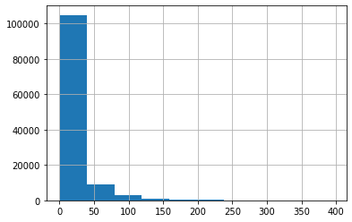

```python
visitor_df['user_id'].value_counts().hist();
```

```python
visitor_df['user_id'].value_counts()[visitor_df['user_id'].value_counts() > 1]
```

```
a118bd9d0e18363f66311c5783fa29e3    395
d77bd8871d35b0850c9de2809b837cd9    392
c103344d9e9ca7df96042392bc768a39    388
6e3edad8c89979d9e03ddd77b9eacbe5    352
69e5aeb30eda03f49c60e6f71011d1ef    338
                                   ...
56f1dea133379203ea235b22aba071e5      2
2817ced3c6d730add3b8ebb8acd414b5      2
1dd50667e7fd9bff0b02ce3d55bacd64      2
b563bdf2da53025a076c39a3af1ffc6a      2
22841bdf6e59073f409a9d5c3d3e96c1      2
Name: user_id, Length: 96656, dtype: int64
```

```python
visitor_df['user_id'].value_counts()[visitor_df['user_id'].value_counts() == 1]
```

```
98770c8cc14b610566b5a32b1c8f5c29    1
a6addb31b1a1ac68e26c70a3d70e698b    1
fc4e1c94760d1166c2cfae04ad8edf80    1
56f850da9cc2ff3c2ca8d0660d9bb2f4    1
7bce0e9e7395b375ac7cb83f3ab64c4b    1
                                   ..
2e06d19a99383818f8db6d96eb95a56b    1
de84f4185451de4752eaf1d9f4dfe8c2    1
b41fb8025086021c45f527a08a59c0db    1
46b19b6dbf7b5c07e6306cfff5633b13    1
a3004beb2a37004d2380b7cd8dd04777    1
Name: user_id, Length: 21921, dtype: int64
```

```python
visitor_df['user_id'].value_counts()[visitor_df['user_id'].value_counts() >= 10]
```

```
a118bd9d0e18363f66311c5783fa29e3    395
d77bd8871d35b0850c9de2809b837cd9    392
c103344d9e9ca7df96042392bc768a39    388
6e3edad8c89979d9e03ddd77b9eacbe5    352
69e5aeb30eda03f49c60e6f71011d1ef    338
                                   ...
368b76a38f229ca2d41f5f97edc24ea7     10
c9aaf9b7966478780c089834f3fb0fc6     10
6af5938f45028d4e3c429b5c58c34cc4     10
8059a64ce8628ce9d3a4534750e1516b     10
2c3b1bd8c9679b89c19db4806451ef7f     10
Name: user_id, Length: 46795, dtype: int64
```

Of the ~119k users, ~22k of them have only one transaction while ~97k have at least 2. And ~47k have at least 10 transactions.

## Comparing country, client, and channel to gauge channel effectiveness

```python
visitor_df.groupby(['ip_country',  'client', 'channel'], as_index=False)['user_id'].count()
```

|  | ip_country | client | channel | user_id |
| --- | --- | --- | --- | --- |
| 0 | A | androidapp | organic | 413834 |
| 1 | A | androidapp | paid | 67873 |
| 2 | A | iosapp | organic | 518339 |
| 3 | A | iosapp | paid | 24471 |
| 4 | A | ipadapp | organic | 28636 |
| 5 | A | ipadapp | paid | 2089 |
| 6 | A | mobileweb | organic | 43167 |
| 7 | A | mobileweb | paid | 933 |
| 8 | A | web | organic | 51676 |
| 9 | A | web | paid | 396 |
| 10 | B | androidapp | organic | 343405 |
| 11 | B | androidapp | paid | 42957 |
| 12 | B | iosapp | organic | 94146 |
| 13 | B | iosapp | paid | 7222 |
| 14 | B | ipadapp | organic | 2292 |
| 15 | B | ipadapp | paid | 262 |
| 16 | B | mobileweb | organic | 24666 |
| 17 | B | mobileweb | paid | 680 |
| 18 | B | web | organic | 50427 |
| 19 | B | web | paid | 677 |
| 20 | C | androidapp | organic | 123304 |
| 21 | C | androidapp | paid | 18527 |
| 22 | C | iosapp | organic | 86174 |
| 23 | C | iosapp | paid | 5187 |
| 24 | C | ipadapp | organic | 6583 |
| 25 | C | ipadapp | paid | 442 |
| 26 | C | mobileweb | organic | 8485 |
| 27 | C | mobileweb | paid | 134 |
| 28 | C | web | organic | 14709 |
| 29 | C | web | paid | 211 |

Paying to get more web users on the platform does not look like a good investment. The proportion of paid users out of web users is lower than on any other platform in any country. The high app based usage should be investigated further, but I'm guessing it's because Wish is mobile focused and may have a user population that is younger.

However, 90% of all users are obtained organically (90%) which is great if true!

## Looking at the customer birth year breakdown

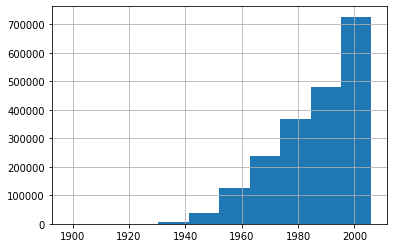

```python
visitor_df['year_born'].hist();
```

A large number of users are 22 or young adults. Those in this bracket may be leaving college and may also be thinking about starting families. This could provide a growth area for products if so.

## Investigating the customer gender breakdown

```python
visitor_df['gender'].value_counts()
```

```
F    1153985
M     825279
O       2640
Name: gender, dtype: int64
```

The customers are mostly female with a very small proportion as Other. Perhaps this could be another interesting growth market? Could non-binary gender customers be encouraged to use the platform more if they're more comfortable with the products offered/app?

## Investigating odd duplicate sessions

```python
duplicate_sessions = visitor_df['session_id'].value_counts()[visitor_df['session_id'].value_counts() > 1].keys().tolist()
print(duplicate_sessions)
```

```
['ecf9ac5ff61783118c5e6df808f7f4d6', '8f35fd9c4c503ba4c88701dc2344675e', 'e322f7d9c4ae0ccec66000ecdb7c5c56', '84aaeef20ee4313f99fcd26636ea0eed', 'ea4a8b964af3ba3b2b7cfcbcdc58c5a7', 'fefffec1384ae38533b306b470f92b45', '2745066e52bf0956dce4657c41309684', 'd3dc0b004ac54ef009a8f3116ba268f6']
```

There are 8 duplicated sessions...these are odd, but the proportion is so low that maybe it isn't worth investigating further

## Aggregate session length effects

```python
transaction_df[transaction_df['user_id'].isin(long_browsers)]['total'].sum()
```

```
5462829.2
```

```python
transaction_df[transaction_df['user_id'].isin(long_browsers)]['total'].sum() / transaction_df[transaction_df['user_id'].isin(long_browsers)]['user_id'].count()
```

```
51.401317299911554
```

```python
transaction_df[transaction_df['user_id'].isin(short_browsers)]['total'].sum()
```

```
6168818.599999999
```

```python
transaction_df[transaction_df['user_id'].isin(short_browsers)]['total'].sum() / transaction_df[transaction_df['user_id'].isin(short_browsers)]['user_id'].count()
```

```
51.222420951242185
```

The average transaction sale per user is not that different between long time sessions (>30 minutes and short time sessions (<=30 minutes). Playing with this threshold could reveal some interesting cutoffs

## Effects of returns

```python
transaction_df[transaction_df['user_id'].isin(paid_users)]['total'][transaction_df[transaction_df['user_id'].isin(paid_users)]['total'] == 0.00]
```

```
16        0.0
23        0.0
34        0.0
35        0.0
49        0.0
         ...
120604    0.0
120608    0.0
120612    0.0
120619    0.0
120642    0.0
Name: total, Length: 7321, dtype: float64
```

```python
transaction_df[transaction_df['user_id'].isin(unpaid_users)]['total'][transaction_df[transaction_df['user_id'].isin(unpaid_users)]['total'] == 0.00]
```

```
16        0.0
23        0.0
32        0.0
34        0.0
35        0.0
         ...
120612    0.0
120615    0.0
120619    0.0
120642    0.0
120643    0.0
Name: total, Length: 10788, dtype: float64
```

## Items sold, but no value recorded

```python
no_value_trans_df = transaction_df[transaction_df['total'] == 0]
no_value_trans_df[(no_value_trans_df['items'] - no_value_trans_df['returned_items']) > 0]
```

|  | user_id | transaction_id | time | country | items | total | returned_items |
| --- | --- | --- | --- | --- | --- | --- | --- |
| 16 | 80c05b9daa082b410ed879f7d1930997 | 50a110bea80c0a4d582e3853f8b87fe2 | 1541186677 | A | 1 | 0.0 | 0 |
| 23 | 28df6361e5f564c9b625ad0b29932bcd | d09068e81ba77fd2ce18454ba9bb8be8 | 1541187254 | C | 1 | 0.0 | 0 |
| 32 | 06b3d9c27754bba6cee975e69623c05b | 8fb3d17bf0721f36344831df6edfe272 | 1541187950 | A | 1 | 0.0 | 0 |
| 49 | 83feffd17eac6e2a06a481a542e1382a | 4173fbb587636ead7895e3624e4429ad | 1541297405 | B | 4 | 0.0 | 0 |
| 50 | ac5efabdbb3c909c0386e7a8671faafb | 6b4da495e0d9abd02fc26f2aafbde3ec | 1541297505 | A | 1 | 0.0 | 0 |
| ... | ... | ... | ... | ... | ... | ... | ... |
| 120608 | dc56aeba27a3d45c8918dd3a4f52089d | f75f9a2cd78918045e1291d55584af8b | 1530871143 | A | 1 | 0.0 | 0 |
| 120615 | 65a472bccc38aaf7a17fccbfa6fd4626 | a15d61c5b5520313da502782d4907d0a | 1532938323 | C | 3 | 0.0 | 0 |
| 120619 | 3c3657c1b1363df5e8201da4be5e1bac | b9571b80e219c2af22e362dfa20e928e | 1526543786 | B | 3 | 0.0 | 0 |
| 120642 | 9423d732fe950bfcfefcf3064cc232da | d5030d123102d3a769d1233c5d5aba2a | 1522660871 | A | 1 | 0.0 | 0 |
| 120643 | a57a32cd0dd2adabfae921d0c8de8ad5 | f16199b664f6590128a171a8abd90c6d | 1522662480 | A | 1 | 0.0 | 0 |

8438 rows × 7 columns

```python
8400 / 120662 *100
```

```
6.961595199814358
```

It is odd that about 7% of transactions are reported this way. Should look into this as some of these transactions have multiple items sold